# Part 2

Christina Maimone

1/16/2020

# Try It Answers

From last time…

1. Make a scatterplot of GDP vs. population using the africa data.

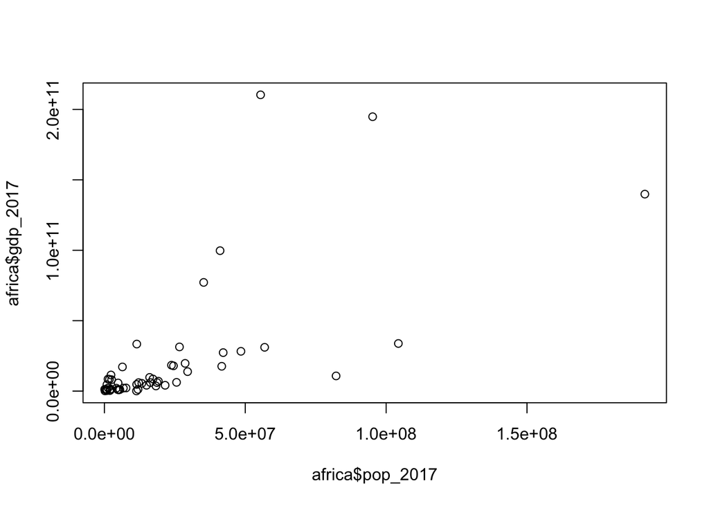

```r
africa <- read.csv("https://nuitrcs.github.io/mmss211R/africadata.csv")
plot(x=africa$pop_2017, y=africa$gdp_2017)
```

Alternate syntax:

```r
plot(gdp_2017 ~ pop_2017, data=africa)
```

2. Which country in Africa has the largest road system (total km of roads)?

```r
max(africa$road)
```

```
## [1] 362099
```

```r
africa[africa$road == max(africa$road),]
```

```
##         country region     gdp_2017 pop_2017    area  rail   road
## 45 South Africa  south 210378257897 55436360 1219090 20500 362099
```

3. Which country in Africa has the highest ratio of km of roads to area (area is in square km)?

```r
africa$road/africa$area
```

```
##  [1] 0.047719314 0.041252106 0.165562914 0.044347034 0.055691051
##  [6] 0.442759612 0.060695356 0.334987593 0.032550002 0.031152648
## [11] 0.472864052 0.065461051 0.049707602 0.254282702 0.132112069
## [16] 0.137231015 0.102673797 0.034098639 0.040169338 0.034258602
## [21] 0.331150442 0.459105391 0.180379078 0.095626903 0.106737082
## [26] 0.195652174 0.095178235 0.047285086 0.063811202 0.130410196
## [31] 0.018121417 0.010311439 1.012745098 0.130769231 0.037943156
## [36] 0.053546689 0.015206788 0.209142968 0.531814730 0.333333333
## [41] 0.075161913 1.104347826 0.156293223 0.034657968 0.297024010
## [46] 0.006331951 0.207027650 0.095858756 0.205176968 0.118684677
## [51] 0.292883461 0.088732544 0.248917494
```

```r
max(africa$road/africa$area)
```

```
## [1] 1.104348
```

```r
africa$road_ratio <- africa$road/africa$area
africa[africa$road_ratio == max(africa$road_ratio),]
```

```
##       country region   gdp_2017 pop_2017 area rail road road_ratio
## 42 Seychelles   east 1261674432    97539  460   NA  508   1.104348
```

# Regression

Function for regression is `lm()`:

```r
lm(road ~ pop_2017 + gdp_2017, data=africa)
```

```
##
## Call:
## lm(formula = road ~ pop_2017 + gdp_2017, data = africa)
##
## Coefficients:
## (Intercept)     pop_2017     gdp_2017
##   1.517e+04    3.084e-04    9.920e-07
```

- `road` is the y (dependent) variable.
- `lm()` automatically adds an intercept (constant) term
- `pop_2017` and `gdp_2017` are independent/predictive/x variables

The above doesn’t give us much info. Let’s save the output:

```r
reg1 <- lm(road ~ pop_2017 + gdp_2017, data=africa)
reg1
```

```
##
## Call:
## lm(formula = road ~ pop_2017 + gdp_2017, data = africa)
##
## Coefficients:
## (Intercept)     pop_2017     gdp_2017
##   1.517e+04    3.084e-04    9.920e-07
```

To get more info, use `summary`:

```r
summary(reg1)
```

```
##
## Call:
## lm(formula = road ~ pop_2017 + gdp_2017, data = africa)
##
## Residuals:
##     Min      1Q  Median      3Q     Max
## -100394  -14841   -8052    3801  121130
##
## Coefficients:
##              Estimate Std. Error t value Pr(>|t|)
## (Intercept) 1.517e+04  5.993e+03   2.532   0.0145 *
## pop_2017    3.084e-04  1.987e-04   1.553   0.1268
## gdp_2017    9.920e-07  1.506e-07   6.588 2.65e-08 ***
## ---
## Signif. codes:  0 '***' 0.001 '**' 0.01 '*' 0.05 '.' 0.1 ' ' 1
##
## Residual standard error: 35670 on 50 degrees of freedom
## Multiple R-squared:  0.6811, Adjusted R-squared:  0.6684
## F-statistic: 53.41 on 2 and 50 DF,  p-value: 3.889e-13
```

If you need to access specific pieces of information from the results, there are two places it might be. First, part of the regression object itself:

```r
names(reg1)
```

```
##  [1] "coefficients"  "residuals"     "effects"       "rank"
##  [5] "fitted.values" "assign"        "qr"            "df.residual"
##  [9] "xlevels"       "call"          "terms"         "model"
```

```r
reg1$coefficients
```

```
##  (Intercept)     pop_2017     gdp_2017
## 1.517354e+04 3.084433e-04 9.920048e-07
```

or part of the results of calling the summary function:

```r
names(summary(reg1))
```

```
##  [1] "call"          "terms"         "residuals"     "coefficients"
##  [5] "aliased"       "sigma"         "df"            "r.squared"
##  [9] "adj.r.squared" "fstatistic"    "cov.unscaled"
```

```r
summary(reg1)$r.squared
```

```
## [1] 0.6811457
```

If you plot the regression object, you get diagnostic plots. Understanding how to interpret these is beyond the scope of this course.

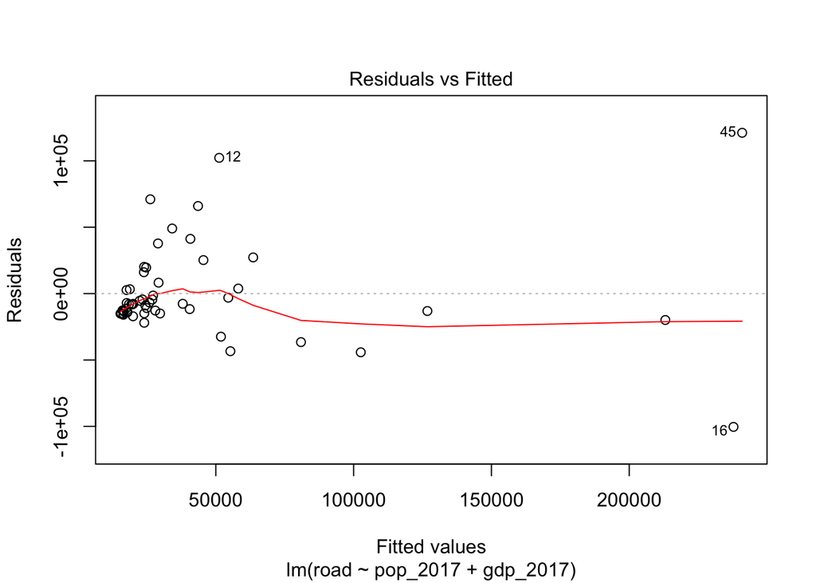

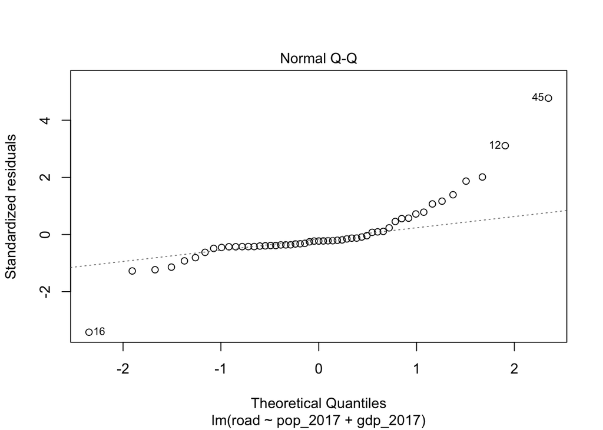

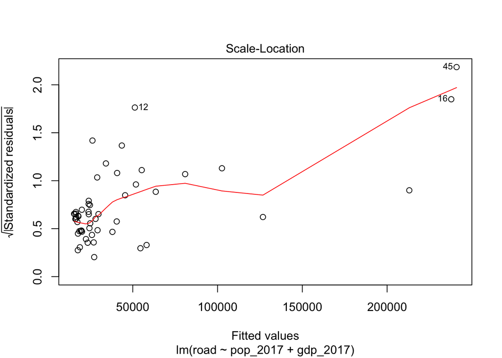

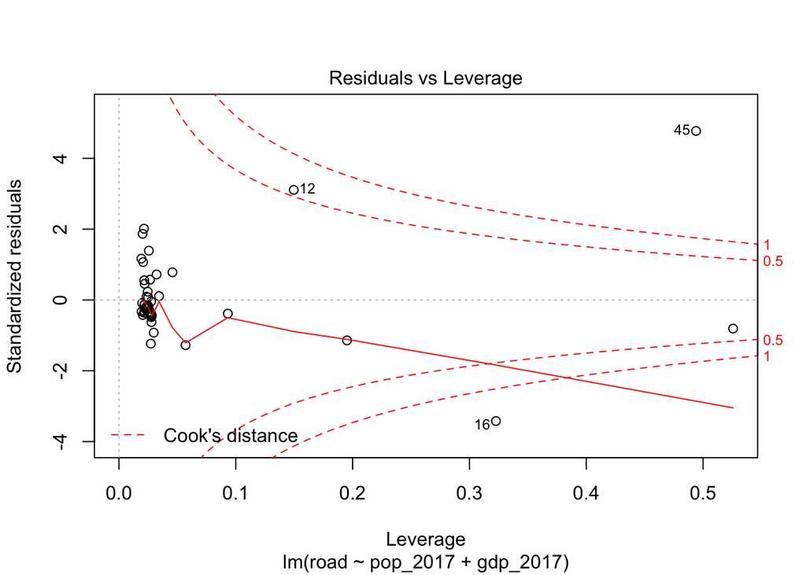

```r
plot(reg1)
```

## Formula Syntax

| Symbol | Example | Description |
| --- | --- | --- |
| `~` | `y ~ x1` | Defines the formula (necessary to create a formula object) |
| `+` | `y ~ x1 + x2` | Include the variable |
| `-` | `y ~ -1 +x1` | Delete a term, usually a 1 for the intercept |
| `:` | `y ~ x1 + x1:x2` | Interaction term |
| `*` | `y ~ x1*x2` | Interaction between the variables and each individually; same as `y ~ x1 + x2 + x1:x2` |
| `I()` | `y ~ I(x1^2)` | Wrapper for transforming variables without having to create a new variable |

There are additional symbols, but these are all of the ones I’ve actually used.

```r
reg2 <- lm(road ~ pop_2017 * gdp_2017, data=africa)
summary(reg2)
```

```
##
## Call:
## lm(formula = road ~ pop_2017 * gdp_2017, data = africa)
##
## Residuals:
##    Min     1Q Median     3Q    Max
## -82513  -9900  -4741   9262 104014
##
## Coefficients:
##                     Estimate Std. Error t value Pr(>|t|)
## (Intercept)        5.825e+03  6.690e+03   0.871  0.38819
## pop_2017           7.879e-04  2.618e-04   3.009  0.00413 **
## gdp_2017           1.378e-06  2.046e-07   6.737  1.7e-08 ***
## pop_2017:gdp_2017 -6.978e-15  2.654e-15  -2.629  0.01140 *
## ---
## Signif. codes:  0 '***' 0.001 '**' 0.01 '*' 0.05 '.' 0.1 ' ' 1
##
## Residual standard error: 33730 on 49 degrees of freedom
## Multiple R-squared:  0.7206, Adjusted R-squared:  0.7035
## F-statistic: 42.12 on 3 and 49 DF,  p-value: 1.316e-13
```

# Resources

- DataCamp courses cover regression in R
- A quick run through: https://nuitrcs.github.io/intro_r_workshop/extratopics/basicstats.html
- UCLA stats consulting: https://stats.idre.ucla.edu/other/dae/